# Assignment Week 6-B.Miller

### Problem 2 - Distribution of Inputs

Visualize the distributions of the quantitative predictors (Term, NoEmp, DisbursementGross) with histograms (feel free to create a separate histogram for each variable) on the training set. Which variable(s) appear to be skewed?

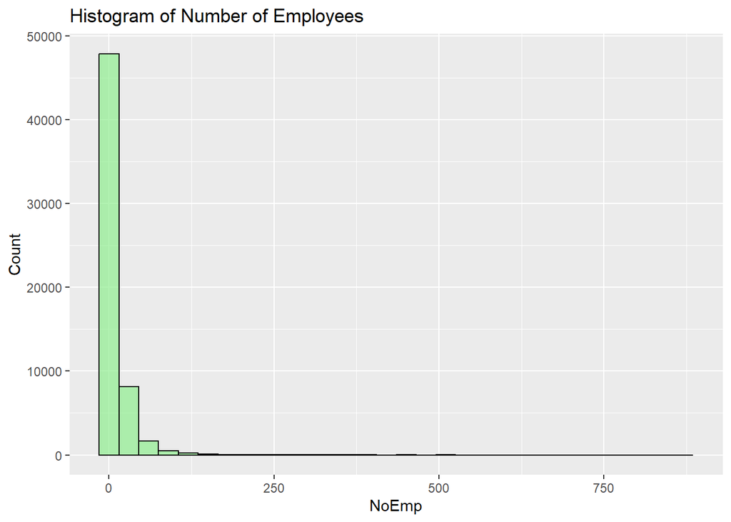

```r
ggplot(train_SBA, aes(x = NoEmp)) +
  geom_histogram(binwidth = 30, fill = "lightgreen", color = "black", alpha = 0.7) +
  labs(title = "Histogram of Number of Employees", x = "NoEmp", y = "Count")
```

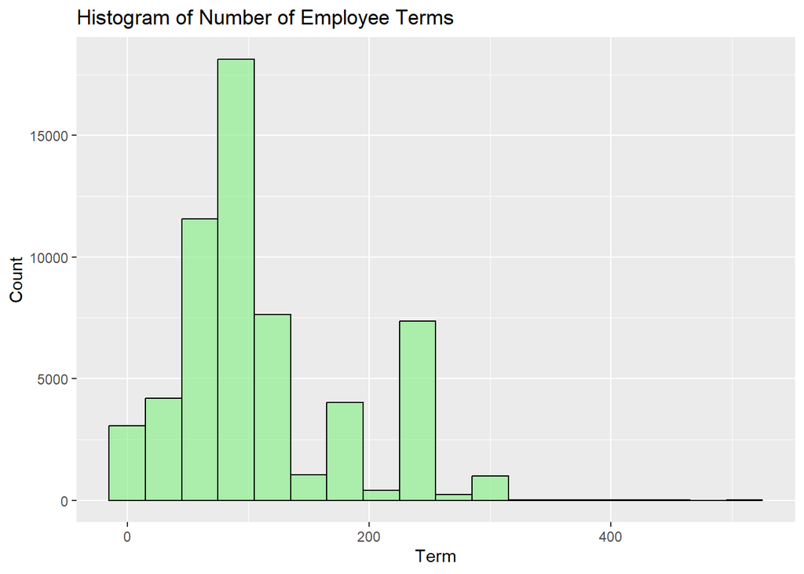

```r
ggplot(train_SBA, aes(x = Term)) +
  geom_histogram(binwidth = 30, fill = "lightgreen", color = "black", alpha = 0.7) +
  labs(title = "Histogram of Number of Employee Terms", x = "Term", y = "Count")
```

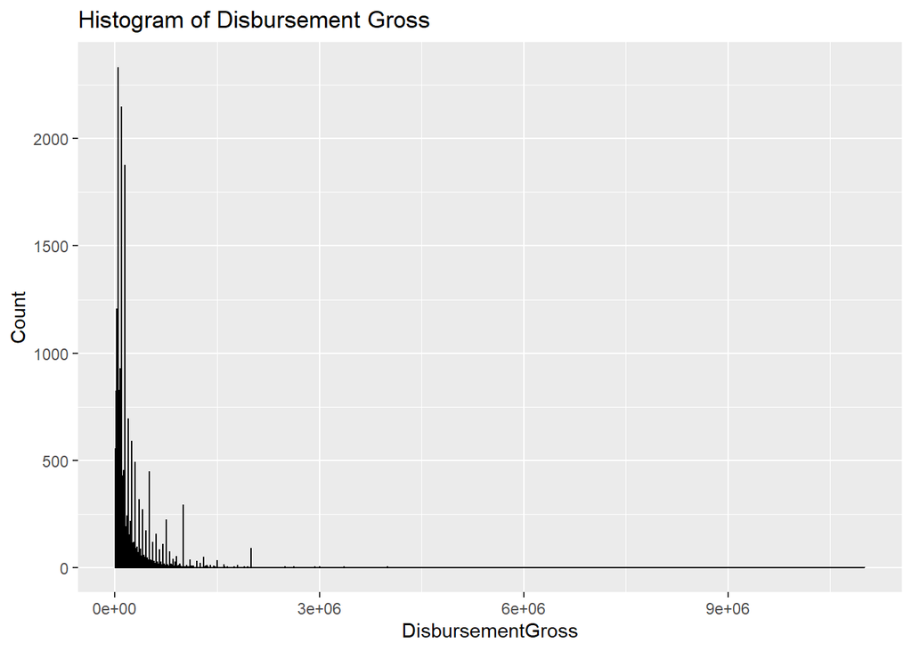

```r
ggplot(train_SBA, aes(x = DisbursementGross)) +
  geom_histogram(binwidth = 100, fill = "lightgreen", color = "black", alpha = 0.7) +
  labs(title = "Histogram of Disbursement Gross", x = "DisbursementGross", y = "Count")
```

### Problem 3 - Box-Cox

Compute the $\lambda$ values for all of the quantitative variables from problem 2 using the preProcess command on the training set. You might have to use the “add one” trick for a few of the variables. What values of $\lambda$ did you get?

```r
boxCox <- SBA_clean[, c("Term", "NoEmp", "DisbursementGross")]

boxCox <- boxCox + 1

pre <- preProcess(boxCox, method = "BoxCox")

pre$bc
```

```
## $Term
## Box-Cox Transformation
##
## 73403 data points used to estimate Lambda
##
## Input data summary:
##    Min. 1st Qu.  Median    Mean 3rd Qu.    Max.
##     1.0    61.0    85.0   110.3   121.0   512.0
##
## Largest/Smallest: 512
## Sample Skewness: 0.967
##
## Estimated Lambda: 0.4
##
##
## $NoEmp
## Box-Cox Transformation
##
## 73403 data points used to estimate Lambda
##
## Input data summary:
##    Min. 1st Qu.  Median    Mean 3rd Qu.    Max.
##    1.00    3.00    6.00   12.44   13.00  859.00
##
## Largest/Smallest: 859
## Sample Skewness: 8.46
##
## Estimated Lambda: -0.3
##
##
## $DisbursementGross
## Box-Cox Transformation
##
## 73403 data points used to estimate Lambda
##
## Input data summary:
##     Min.  1st Qu.   Median     Mean  3rd Qu.     Max.
##     4001    50001   100001   195953   227001 11000001
##
## Largest/Smallest: 2750
## Sample Skewness: 5.79
##
## Estimated Lambda: 0
## With fudge factor, Lambda = 0 will be used for transformations
```

### Problem 4 - Distribution of variables post-transform

Use predict to execute the transformations. Visualize the quantitative variables after transformation on the training set.

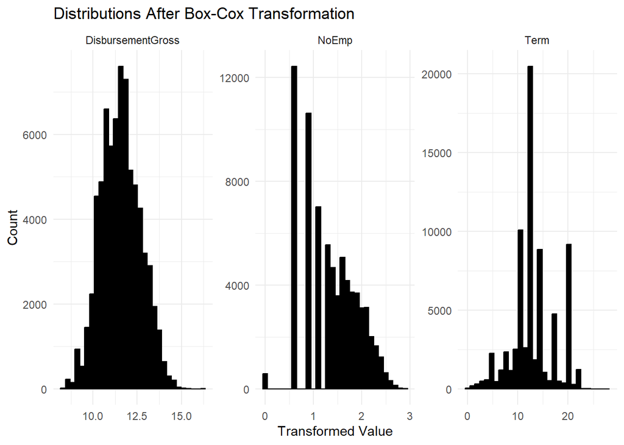

```r
tData <- predict(pre,boxCox)

cdata <- tData %>%
  pivot_longer(
    cols = everything(), names_to = "Variable", values_to = "Value"
  )

ggplot(cdata, aes(x = Value)) +
  geom_histogram(bins = 30, fill = "black", color = "black") +
  facet_wrap(~Variable, scales = "free") +
  theme_minimal() +
  labs(title = "Distributions After Box-Cox Transformation",
       x = "Transformed Value",
       y = "Count")
```

### Problem 5 - Build/Test Model

Use the transformed training data as input to a logistic model.

Transform the test data. Don’t forget to transform the test data in the same way that you transformed the training data (using the preprocessing values from the training set).

Compare the performance (ROC area under the curve) on the transformed test set to our baseline (model5).

```r
trainQuant <- train_SBA[, c("Term","NoEmp","DisbursementGross")]

testQuant <- test_SBA[,c("Term","NoEmp","DisbursementGross")]

trainQuant <- trainQuant + 1

testQuant <- testQuant +1

train_t <- predict(pre, trainQuant)
test_t  <- predict(pre, testQuant)

train_new <- train_SBA
test_new  <- test_SBA

train_new[, c("Term", "NoEmp", "DisbursementGross")] <- train_t
test_new[,  c("Term", "NoEmp", "DisbursementGross")] <- test_t

model_base <- glm(Loan_Status ~ .,
                  data = train_SBA,
                  family = binomial)

model2 <- glm(Loan_Status ~ .,
                data = train_new,
                family = binomial)

prob2 <- predict(model2,
                   newdata = test_new,
                   type = "response")

prob_base <- predict(model_base,
                     newdata = test_SBA,
                     type = "response")

roc_base <- roc(test_SBA$Loan_Status, prob_base)
auc_base <- auc(roc_base)

roc_bc <- roc(test_new$Loan_Status, prob2)
auc_bc <- auc(roc_bc)

auc_bc
```

```
## Area under the curve: 0.8023
```

```r
auc_bc - auc_base
```

```
## [1] 0.004827803
```

```r
#The transformation model improved by 0.0048 from 0.7975 to 0.8023
```

### Problem 6 - Nonlinear terms

Experiment with some additional nonlinear terms for some of the quantitative variables (DisbursementGross, NoEmp, Term). Do they improve the ROC area under the curve?

```r
model3 <- glm(
 Loan_Status ~ . +
    I(Term^2),
  data = train_new,
  family = binomial
)

probNl <- predict(model3,
                   newdata = test_new,
                   type = "response")

rocNl <- roc(test_new$Loan_Status, probNl)
aucNl <- auc(rocNl)

aucNl
```

```
## Area under the curve: 0.8034
```

```r
model4 <- glm(
 Loan_Status ~ . +
    I(NoEmp^2),
  data = train_new,
  family = binomial
)

probNl2 <- predict(model4,
                   newdata = test_new,
                   type = "response")

rocNl2 <- roc(test_new$Loan_Status, probNl2)
aucNl2 <- auc(rocNl2)

aucNl2
```

```
## Area under the curve: 0.8051
```

```r
#There is small consistant improvement.
```